# AS2-1: 數位偵探

第 4 組

2019-09-30 18:54:48

基本的程式筆記設定，安裝、載入一些基本的套件

```r
rm(list=ls(all=T))
knitr::opts_chunk$set(comment = NA)
knitr::opts_knit$set(global.par = TRUE)
par(cex=0.8); options(scipen=20, digits=4, width=90)
if(!require(pacman)) install.packages("pacman")
pacman::p_load(magrittr, d3heatmap)
```

以上這些程式碼請大家不要去改動

犯罪是一個國際關注的問題，但它在不同的國家以不同的方式記錄和處理。 在美國，聯邦調查局（FBI）記錄了暴力犯罪和財產犯罪。 此外，每個城市都記錄了犯罪行為，一些城市發布了有關犯罪率的數據。 伊利諾伊州芝加哥市從2001年開始在線發布犯罪數據。

芝加哥是美國人口第三多的城市，人口超過270萬。在這個作業裡面，我們將關注一種特定類型的財產犯罪，稱為「汽車盜竊」，我們將使用R中的一些基本數據分析來了解芝加哥的汽車盜竊紀錄。請載入文件“data/mvtWeek1.csv”：以下是各欄位的描述：

- `ID`: a unique identifier for each observation
- `Date`: the date the crime occurred
- `LocationDescription`: the location where the crime occurred
- `Arrest`: whether or not an arrest was made for the crime (TRUE if an arrest was made, and FALSE if an arrest was not made)
- `Domestic`: whether or not the crime was a domestic crime, meaning that it was committed against a family member (TRUE if it was domestic, and FALSE if it was not domestic)
- `Beat`: the area, or “beat” in which the crime occurred. This is the smallest regional division defined by the Chicago police department.
- `District`: the police district in which the crime occured. Each district is composed of many beats, and are defined by the Chicago Police Department.
- `CommunityArea`: the community area in which the crime occurred. Since the 1920s, Chicago has been divided into what are called “community areas”, of which there are now 77. The community areas were devised in an attempt to create socially homogeneous regions.
- `Year`: the year in which the crime occurred.
- `Latitude`: the latitude of the location at which the crime occurred.
- `Longitude`: the longitude of the location at which the crime occurred.

### Section-1 Loading the Data

【1.1】How many rows of data (observations) are in this dataset?

```r
D=read.csv("data/mvtWeek1.csv", stringsAsFactors=F)
nrow(D)
```

```
[1] 191641
```

```r
ncol(D)
```

```
[1] 11
```

檢查各欄位的資料格式

```r
summary(D)
```

```
       ID              Date           LocationDescription   Arrest         Domestic
 Min.   :1310022   Length:191641      Length:191641       Mode :logical   Mode :logical
 1st Qu.:2832144   Class :character   Class :character    FALSE:176105    FALSE:191226
 Median :4762956   Mode  :character   Mode  :character    TRUE :15536     TRUE :415
 Mean   :4968629
 3rd Qu.:7201878
 Max.   :9181151

      Beat         District     CommunityArea        Year         Latitude
 Min.   : 111   Min.   : 1      Min.   : 0      Min.   :2001   Min.   :41.6
 1st Qu.: 722   1st Qu.: 6      1st Qu.:22      1st Qu.:2003   1st Qu.:41.8
 Median :1121   Median :10      Median :32      Median :2006   Median :41.9
 Mean   :1259   Mean   :12      Mean   :38      Mean   :2006   Mean   :41.8
 3rd Qu.:1733   3rd Qu.:17      3rd Qu.:60      3rd Qu.:2009   3rd Qu.:41.9
 Max.   :2535   Max.   :31      Max.   :77      Max.   :2012   Max.   :42.0
                NA's   :43056   NA's   :24616                  NA's   :2276
   Longitude
 Min.   :-87.9
 1st Qu.:-87.7
 Median :-87.7
 Mean   :-87.7
 3rd Qu.:-87.6
 Max.   :-87.5
 NA's   :2276
```

類別(Factor) versus 字串(Character)

【1.2】How many variables are in this dataset?

```r
ncol(D)
```

```
[1] 11
```

【1.3】Using the “max” function, what is the maximum value of the variable “ID”?

```r
max(D$ID)
```

```
[1] 9181151
```

【1.4】 What is the minimum value of the variable “Beat”?

```r
min(D$Beat)
```

```
[1] 111
```

【1.5】 How many observations have value TRUE in the Arrest variable (this is the number of crimes for which an arrest was made)?

```r
sum(D$Arrest)
```

```
[1] 15536
```

```r
mean(D$Arrest)
```

```
[1] 0.08107
```

【1.6】 How many observations have a LocationDescription value of ALLEY?

```r
sum(D$LocationDescription=="ALLEY")
```

```
[1] 2308
```

使用`sum()`和`mean()`來計算邏輯運算結果的數量和比率

### Section-2 Understanding Dates in R

【2.1】 In what format are the entries in the variable Date?

- Month/Day/Year Hour:Minute
- Day/Month/Year Hour:Minute
- Hour:Minute Month/Day/Year
- Hour:Minute Day/Month/Year

```r
head(D$Date) #Month/Day/Year Hour:Minute
```

```
[1] "12/31/12 23:15" "12/31/12 22:00" "12/31/12 22:00" "12/31/12 22:00" "12/31/12 21:30"
[6] "12/31/12 20:30"
```

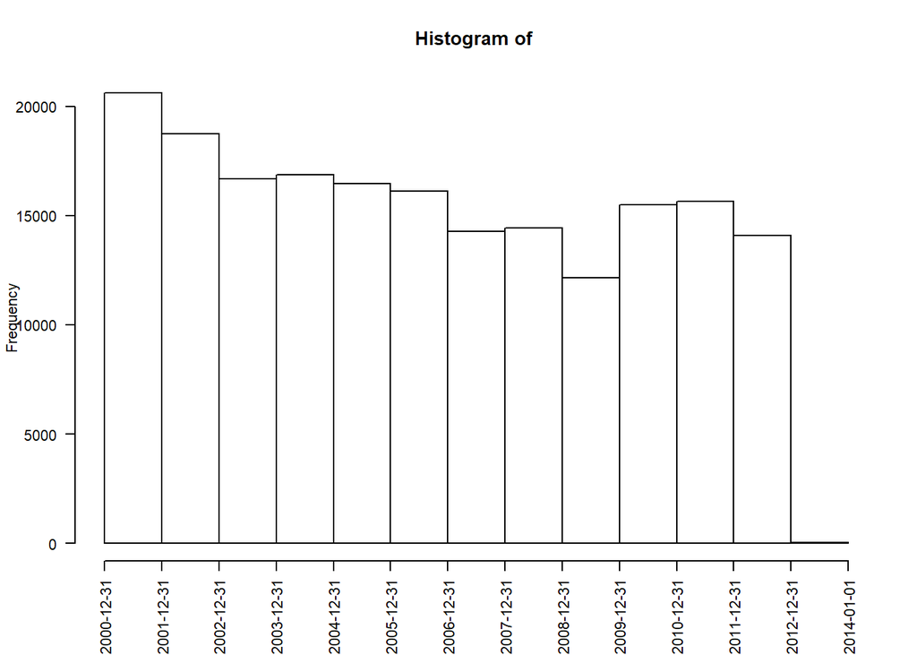

```r
ts=as.POSIXct(D$Date, format="%m/%d/%y %H:%M")
par(cex=0.7)
hist(ts, "year", las=2, freq=T, xlab="")
```

二維的`table()`

```r
table(format(ts,"%w"))
```

```
    0     1     2     3     4     5     6
26316 27397 26791 27416 27319 29284 27118
```

```r
table(format(ts,"%m"))
```

```
   01    02    03    04    05    06    07    08    09    10    11    12
16047 13511 15758 15280 16035 16002 16801 16572 16060 17086 16063 16426
```

```r
table(weekday=format(ts,"%w"),month=format(ts,"%m"))
```

```
       month
weekday   01   02   03   04   05   06   07   08   09   10   11   12
      0 2110 1837 2075 2070 2168 2239 2339 2304 2352 2424 2254 2144
      1 2395 1937 2200 2323 2359 2187 2457 2288 2258 2399 2323 2271
      2 2317 1885 2270 2118 2222 2183 2412 2251 2142 2416 2258 2317
      3 2259 2007 2242 2060 2345 2347 2408 2428 2239 2484 2182 2415
      4 2334 1904 2263 2099 2402 2190 2385 2464 2320 2280 2253 2425
      5 2392 2036 2443 2388 2340 2566 2459 2591 2390 2692 2475 2512
      6 2240 1905 2265 2222 2199 2290 2341 2246 2359 2391 2318 2342
```

二維矩陣的視覺化

```r
table(format(ts, "%u"), format(ts, "%H")) %>%
  as.data.frame.matrix %>%
  d3heatmap(F, F, col=colorRamp(c("seagreen", "lightyellow", "red")))
```

[interactive chart not shown]

【2.2】 What is the month and year of the median date in our dataset?

```r
median(ts)
```

```
[1] "2006-05-21 12:30:00 CST"
```

【2.3】 In which month did the fewest motor vehicle thefts occur?

2月

```r
sort(table(format(ts, "%m")))
```

```
   02    04    03    06    05    01    09    11    12    08    07    10
13511 15280 15758 16002 16035 16047 16060 16063 16426 16572 16801 17086
```

【2.4】 On which weekday did the most motor vehicle thefts occur?

星期五

```r
sort(table(format(ts, "%w")))
```

```
    0     2     6     4     1     3     5
26316 26791 27118 27319 27397 27416 29284
```

【2.5】 Which month has the largest number of motor vehicle thefts for which an arrest was made?

1月

```r
ts[D$Arrest] %>% format("%m") %>% table %>% sort
```

```
.
  05   06   02   09   04   11   03   07   08   10   12   01
1187 1230 1238 1248 1252 1256 1298 1324 1329 1342 1397 1435
```

### Section-3 Visualizing Crime Trends

【3.1】 (a) In general, does it look like crime increases or decreases from 2002 - 2012? (b) In general, does it look like crime increases or decreases from 2005 - 2008? (c) In general, does it look like crime increases or decreases from 2009 - 2011?

(a)2002-2012 : decrease ; (b)2005-2008 : decrease ; (c)2009-2011 : increase

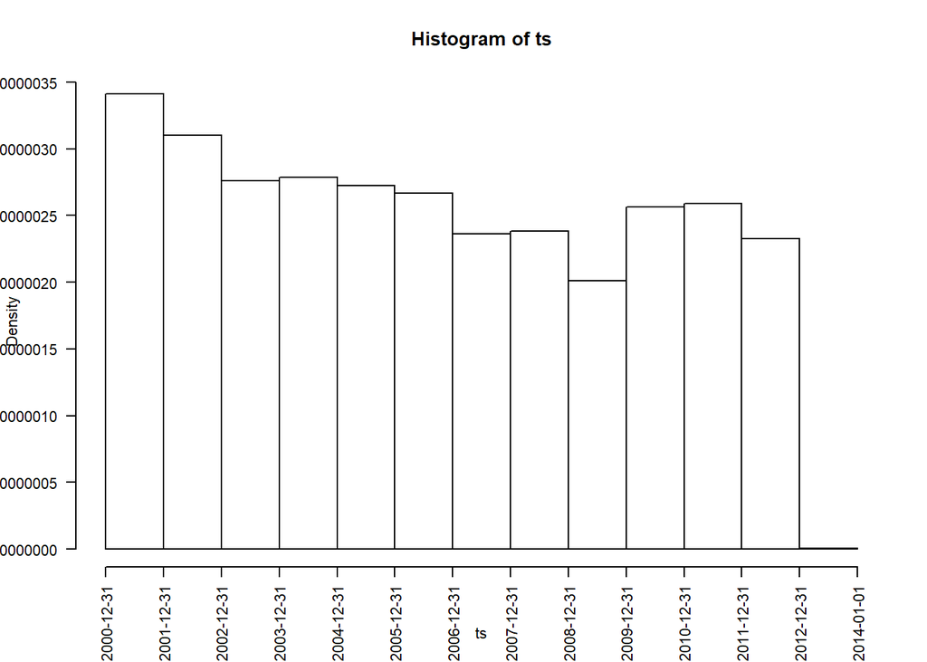

```r
hist(ts, "year", las=2)
```

【3.2】 Does it look like there were more crimes for which arrests were made in the first half of the time period or the second half of the time period?

```r
table(ts>as.POSIXct("2007-01-01"))
```

```
 FALSE   TRUE
105523  86118
```

【3.3】 For what proportion of motor vehicle thefts in 2001 was an arrest made?

0.104

```r
table(D$Arrest, format(ts, "%Y")) %>% prop.table(2) %>% round(3)
```

```
         2001  2002  2003  2004  2005  2006  2007  2008  2009  2010  2011  2012
  FALSE 0.896 0.887 0.892 0.900 0.907 0.919 0.915 0.929 0.931 0.955 0.960 0.961
  TRUE  0.104 0.113 0.108 0.100 0.093 0.081 0.085 0.071 0.069 0.045 0.040 0.039
```

【3.4】 For what proportion of motor vehicle thefts in 2007 was an arrest made?

0.085

```r
tapply(D$Arrest, format(ts, "%Y"), mean) %>% round(3)
```

```
 2001  2002  2003  2004  2005  2006  2007  2008  2009  2010  2011  2012
0.104 0.113 0.108 0.100 0.093 0.081 0.085 0.071 0.069 0.045 0.040 0.039
```

【3.5】 For what proportion of motor vehicle thefts in 2012 was an arrest made?

```r
#0.039
```

### Section-4 Popular Locations

【4.1】 Which locations are the top five locations for motor vehicle thefts, excluding the “Other” category? You should select 5 of the following options.

```r
table(D$LocationDescription) %>% sort %>% tail(6)
```

```
        DRIVEWAY - RESIDENTIAL                    GAS STATION
                          1675                           2111
                         ALLEY                          OTHER
                          2308                           4573
PARKING LOT/GARAGE(NON.RESID.)                         STREET
                         14852                         156564
```

【4.2】 How many observations are in Top5?

```r
top5=names(table(D$LocationDescription) %>% sort %>% tail(6))[-4]
sum(D$LocationDescription %in% top5)
```

```
[1] 177510
```

【4.3】 One of the locations has a much higher arrest rate than the other locations. Which is it?

GAS STATION

```r
TOP5=subset(D, LocationDescription %in% top5)
tapply(TOP5$Arrest, TOP5$LocationDescription, mean) %>% sort
```

```
                        STREET         DRIVEWAY - RESIDENTIAL
                       0.07406                        0.07881
                         ALLEY PARKING LOT/GARAGE(NON.RESID.)
                       0.10789                        0.10793
                   GAS STATION
                       0.20796
```

【4.4】 On which day of the week do the most motor vehicle thefts at gas stations happen?

星期六

```r
ts[D$Location == "GAS STATION"] %>% format("%w") %>% table %>% sort
```

```
.
  2   3   1   4   5   0   6
270 273 280 282 332 336 338
```

【4.5】 On which day of the week do the fewest motor vehicle thefts in residential driveways happen?

```r
ts[D$Location == "DRIVEWAY - RESIDENTIAL"] %>%
  format("%w") %>% table %>% sort
```

```
.
  6   0   3   2   1   5   4
202 221 234 243 255 257 263
```